# Final Project

Getting gun violence and county census data.

```r
gunViolence <- fread("gunViolenceGeo.csv")
countyCensus <- fread("https://raw.githubusercontent.com/dilernia/STA418-518/main/Data/census_data_county_2009-2021.csv")
```

# Data Dictionary

## Dictionary for `gunViolence` Data

```r
# Creating gunViolence data dictionary
gunViolenceDictionary <- tibble(Variable = colnames(gunViolence),
                         Description = c("FIPS code for county",
                                         "Incident ID number",
                                         "Date recorded (Jan 1, 2013 - Mar 31, 2018)",
                                         "State",
                                         "City or county",
                                         "Street address incident took place",
                                         "Number of people killed",
                                         "Number of people injured",
                                         "URL to the incident on the gunviolencearchive.org site",
                                         "URL to the source article for the incident",
                                         "Whether or not the incidenturl field is missing",
                                         "Congressional district number (Ranges from 0 - 54)",
                                         "Whether guns used in the incident were stolen (Gun number::Whether it was stolen or not, if known)",
                                         "Type of gun used (Gun number::What type of gun, if known)",
                                         "Characteristics about the incident (Whether shots were fired, type of area it took place, if someone was killed or injured, etc.)",
                                         "Latitude incident took place",
                                         "Discription of the location the incident took place such as a building name",
                                         "Longitude incident took place",
                                         "Number of guns involved",
                                         "Additional notes from reports or if there is a discrepency in information, it is noted here",
                                         "Age of participant (Participant number::Age)",
                                         "Age group of participant (Adult (18+), Teen (12-17), or Child (0-11)) (Participant number::Age group)",
                                         "Gender of participant (Participant number::Gender)",
                                         "Name of participant (Participant number::Name)",
                                         "How participants are related (EX: Family, Gang, Aquaintance, Mass Shooting, etc.) (Group number::Relation)",
                                         "Status of participant (EX: Injured, Killed, Unharmed, Arrested) (Participant number::Status)",
                                         "Type of participant (EX: Victim, Subject-Suspect) (Participant number::Type)",
                                         "Sources used for the webpage",
                                         "State house district (0 - 950)",
                                         "State senate district (0 - 95)",
                                         "Full address of incident"),
                         Type = map_chr(gunViolence, .f = function(x){typeof(x)[1]}),
                         Class = map_chr(gunViolence, .f = function(x){class(x)[1]}))

knitr::kable(gunViolenceDictionary)
```

| Variable | Description | Type | Class |
| --- | --- | --- | --- |
| geoid | FIPS code for county | integer | integer |
| incident_id | Incident ID number | integer | integer |
| date | Date recorded (Jan 1, 2013 - Mar 31, 2018) | integer | IDate |
| state | State | character | character |
| city_or_county | City or county | character | character |
| address | Street address incident took place | character | character |
| n_killed | Number of people killed | integer | integer |
| n_injured | Number of people injured | integer | integer |
| incident_url | URL to the incident on the gunviolencearchive.org site | character | character |
| source_url | URL to the source article for the incident | character | character |
| incident_url_fields_missing | Whether or not the incidenturl field is missing | logical | logical |
| congressional_district | Congressional district number (Ranges from 0 - 54) | integer | integer |
| gun_stolen | Whether guns used in the incident were stolen (Gun number::Whether it was stolen or not, if known) | character | character |
| gun_type | Type of gun used (Gun number::What type of gun, if known) | character | character |
| incident_characteristics | Characteristics about the incident (Whether shots were fired, type of area it took place, if someone was killed or injured, etc.) | character | character |
| lat | Latitude incident took place | double | numeric |
| location_description | Discription of the location the incident took place such as a building name | character | character |
| long | Longitude incident took place | double | numeric |
| n_guns_involved | Number of guns involved | integer | integer |
| notes | Additional notes from reports or if there is a discrepency in information, it is noted here | character | character |
| participant_age | Age of participant (Participant number::Age) | character | character |
| participant_age_group | Age group of participant (Adult (18+), Teen (12-17), or Child (0-11)) (Participant number::Age group) | character | character |
| participant_gender | Gender of participant (Participant number::Gender) | character | character |
| participant_name | Name of participant (Participant number::Name) | character | character |
| participant_relationship | How participants are related (EX: Family, Gang, Aquaintance, Mass Shooting, etc.) (Group number::Relation) | character | character |
| participant_status | Status of participant (EX: Injured, Killed, Unharmed, Arrested) (Participant number::Status) | character | character |
| participant_type | Type of participant (EX: Victim, Subject-Suspect) (Participant number::Type) | character | character |
| sources | Sources used for the webpage | character | character |
| state_house_district | State house district (0 - 950) | integer | integer |
| state_senate_district | State senate district (0 - 95) | integer | integer |
| address_full | Full address of incident | character | character |

### Missingness in `gunViolence`

```r
# Creating a table for number of missing values in each column of the gunViolence data set
knitr::kable(colSums(is.na(gunViolence)) / nrow(gunViolence) * 100, col.names = c("Variable Name", "Percent Missing"))
```

| Variable Name | Percent Missing |
| --- | --- |
| geoid | 3.3482562 |
| incident_id | 0.0000000 |
| date | 0.0000000 |
| state | 0.0000000 |
| city_or_county | 0.0000000 |
| address | 6.8830134 |
| n_killed | 0.0000000 |
| n_injured | 0.0000000 |
| incident_url | 0.0000000 |
| source_url | 0.1952628 |
| incident_url_fields_missing | 0.0000000 |
| congressional_district | 4.9833735 |
| gun_stolen | 41.5133701 |
| gun_type | 41.4937604 |
| incident_characteristics | 0.1360164 |
| lat | 3.3056989 |
| location_description | 82.4392829 |
| long | 3.3056989 |
| n_guns_involved | 41.4937604 |
| notes | 33.8025760 |
| participant_age | 38.5093271 |
| participant_age_group | 17.5732340 |
| participant_gender | 15.1712513 |
| participant_name | 51.0073975 |
| participant_relationship | 93.4186426 |
| participant_status | 11.5263459 |
| participant_type | 10.3735444 |
| sources | 0.2540920 |
| state_house_district | 16.1767712 |
| state_senate_district | 13.4910734 |
| address_full | 3.3107057 |

As shown in the table above, much of the Gun Violence data set is missing, most notably `participant_relationship`, `location_description`, and `participant_name` all have more missing values than actual data. To avoid issues with the data set, I will focus on using rows with much less missingness such as `date`, `state`, `city_or_county`, `n_killed`, and `n_injured` which are all fully present in the data set as well as `address_full` which has only 3.31% missingness.

## Dictionary for `countyCensus` Data

```r
# Creating countyCensus data dictionary
countyDictionary <- tibble(Variable = colnames(countyCensus),
                         Description = c("FIPS code for county",
                                         "County, State",
                                         "Year recorded (2009 - 2021)",
                                         "Population of county",
                                         "Median income for county (USD)",
                                         "Median rent cost per month (USD)",
                                         "Median home cost per month (USD)",
                                         "Proportion of females in county",
                                         "Proportion of males in county",
                                         "Proportion of county in poverty"),
                         Type = map_chr(countyCensus, .f = function(x){typeof(x)[1]}),
                         Class = map_chr(countyCensus, .f = function(x){class(x)[1]}))

knitr::kable(countyDictionary)
```

| Variable | Description | Type | Class |
| --- | --- | --- | --- |
| geoid | FIPS code for county | integer | integer |
| county_state | County, State | character | character |
| year | Year recorded (2009 - 2021) | integer | integer |
| population | Population of county | integer | integer |
| median_income | Median income for county (USD) | integer | integer |
| median_monthly_rent_cost | Median rent cost per month (USD) | integer | integer |
| median_monthly_home_cost | Median home cost per month (USD) | integer | integer |
| prop_female | Proportion of females in county | double | numeric |
| prop_male | Proportion of males in county | double | numeric |
| prop_poverty | Proportion of county in poverty | double | numeric |

### Missingness in `countyCensus`

```r
skimr::skim(countyCensus)
```

Data summary

| Name | countyCensus |
| --- | --- |
| Number of rows | 41867 |
| Number of columns | 10 |
| Key | NULL |
| _______________________ |  |
| Column type frequency: |  |
| character | 1 |
| numeric | 9 |
| ________________________ |  |
| Group variables | None |

**Variable type: character**

| skim_variable | n_missing | complete_rate | min | max | empty | n_unique | whitespace |
| --- | --- | --- | --- | --- | --- | --- | --- |
| county_state | 0 | 1 | 16 | 42 | 0 | 3228 | 0 |

**Variable type: numeric**

| skim_variable | n_missing | complete_rate | mean | sd | p0 | p25 | p50 | p75 | p100 | hist |
| --- | --- | --- | --- | --- | --- | --- | --- | --- | --- | --- |
| geoid | 0 | 1 | 31394.62 | 16291.12 | 1001.00 | 19032.00 | 30025.00 | 46107.00 | 72153.00 | ▅▇▆▆▁ |
| year | 0 | 1 | 2015.00 | 3.74 | 2009.00 | 2012.00 | 2015.00 | 2018.00 | 2021.00 | ▇▅▇▅▇ |
| population | 0 | 1 | 99198.02 | 318133.15 | 41.00 | 11218.00 | 25987.00 | 66375.50 | 10105722.00 | ▇▁▁▁▁ |
| median_income | 4 | 1 | 48034.94 | 14258.33 | 10499.00 | 39167.00 | 46215.00 | 54732.00 | 156821.00 | ▃▇▁▁▁ |
| median_monthly_rent_cost | 30 | 1 | 703.80 | 214.98 | 99.00 | 567.00 | 658.00 | 784.00 | 2599.00 | ▅▇▁▁▁ |
| median_monthly_home_cost | 18 | 1 | 775.03 | 356.61 | 103.00 | 543.00 | 684.00 | 910.00 | 3254.00 | ▇▅▁▁▁ |
| prop_female | 0 | 1 | 0.50 | 0.02 | 0.19 | 0.49 | 0.50 | 0.51 | 0.63 | ▁▁▁▇▁ |
| prop_male | 0 | 1 | 0.50 | 0.02 | 0.37 | 0.49 | 0.50 | 0.51 | 0.81 | ▁▇▁▁▁ |
| prop_poverty | 1 | 1 | 0.17 | 0.08 | 0.00 | 0.11 | 0.15 | 0.20 | 0.67 | ▆▇▁▁▁ |

The County Census data has a very low missingness. No variable has less than a 99.9% complete rate. This means that the missing values should not impact the data set in meaningful ways.

# Data Cleaning

## Merging Data Sets

Merging both the `gunViolence` and `countyCensus` data sets into a `gunViolenceWithCensus` data set.

```r
# Getting a year variable for gunViolence
gunViolence <- gunViolence %>%
  dplyr::mutate(year = year(date))

# Merging the gunViolence and countyCensus data
gunViolenceWithCensus <- gunViolence %>%
  left_join(countyCensus, by = c("geoid", "year"))
```

## String Manipulation

Creating a `street` variable in `gunViolenceWithCensus` with the street, city, and state of each incident.

```r
# Creating a street variable without the address numbers or zip code
gunViolenceWithCensus <- gunViolenceWithCensus %>%
  dplyr::mutate(street = str_remove_all(address_full, pattern = regex("[:digit:]+,"))) %>%
  dplyr::mutate(street = str_remove_all(street, pattern = regex("1$")))
```

Creating an `arrested` variable for the number of people arrested in each gun violence incident.

```r
# Counting the number of people arrested in each gun violence incident
gunViolenceWithCensus <- gunViolenceWithCensus %>%
  dplyr::mutate(num_arrested = str_count(str_to_lower(participant_status), pattern = "arrested"))
```

Creating variables for the `day` and `month` of each incident.

```r
# Creating seperate year, month, and day columns for gunViolenceWithCensus
gunViolenceWithCensus <- gunViolenceWithCensus %>%
  dplyr::mutate(month = substr(date, 6, 7)) %>%
  dplyr::mutate(day = substr(date, 9, 10))
```

# Exploratory Data Analysis

## Tables of Summary Statistics

Getting the 10 streets with the highest number of reported gun violence incidents in the United States.

```r
# Table with the streets with the most gun violence incidents
gunViolenceWithCensus %>%
  dplyr::filter(!is.na(street)) %>%
  dplyr::group_by(street) %>%
  dplyr::count() %>%
  dplyr::ungroup() %>%
  dplyr::arrange(desc(n)) %>%
  dplyr::slice_head(n = 10) %>%
  knitr::kable(col.names = c("Street", "Number of Incidents"), caption = "Table 1: Streets with the most reported gun violence incidents January 2013 - March 2018")
```

Table 1: Streets with the most reported gun violence incidents January 2013 - March 2018

| Street | Number of Incidents |
| --- | --- |
| Hartsfield–Jackson Atlanta International Airport, North Terminal Parkway, Atlanta, Clayton County, Georgia, United States | 258 |
| North Howard Street, Chinatown, Downtown, Baltimore, Maryland, United States | 236 |
| Terminal A/B Parking, South Terminal Road, Houston, Harris County, Texas, United States | 169 |
| Whataburger, International Parkway, Grapevine, Tarrant County, Texas, United States | 160 |
| Service Road, Phoenix, Maricopa County, Arizona, United States | 159 |
| 5th Street Northwest, Shaw, Logan Circle/Shaw, Washington, District of Columbia, United States | 135 |
| Deming Pavilion, South Saratoga Street, Storyville, New Orleans, Orleans Parish, Louisiana, United States | 109 |
| Rental Car Facilites, Jeff Fuqua Boulevard, Orlando, Orange County, Florida, United States | 104 |
| Jeppesen Terminal, Peña Boulevard, Denver, Colorado, United States | 102 |
| Dero, Spokane River Centennial Trail, Kendall Yards, Spokane, Spokane County, Washington, United States | 99 |

Getting a table for the average number of gun violence incidents in Illinois counties per year between 2014 and 2017.

```r
# Creating table for average # of incidents per year for each Illinois county
gunViolenceWithCensus %>%
  dplyr::filter(!is.na(county_state)) %>%
  dplyr::group_by(county_state, year) %>%
  dplyr::filter(state == "Illinois" ) %>%
  dplyr::filter(year != 2013 & year != 2018) %>%
  dplyr::count() %>%
  dplyr::ungroup() %>%
  dplyr::group_by(county_state) %>%
  dplyr::summarize(incidents = mean(n)) %>%
  dplyr::ungroup() %>%
  dplyr::arrange(desc(incidents)) %>%
  dplyr::slice_head(n = 10) %>%
  knitr::kable(col.names = c("County", "Number of Incidents"), caption = "Table 2: Average number of gun violence incidents in Illinois counties per year from 2014 - 2017")
```

Table 2: Average number of gun violence incidents in Illinois counties per year from 2014 - 2017

| County | Number of Incidents |
| --- | --- |
| Cook County, Illinois | 2825.25 |
| Peoria County, Illinois | 217.00 |
| Winnebago County, Illinois | 200.25 |
| Champaign County, Illinois | 83.75 |
| St. Clair County, Illinois | 83.75 |
| Sangamon County, Illinois | 75.25 |
| Will County, Illinois | 71.50 |
| Kane County, Illinois | 59.50 |
| Kankakee County, Illinois | 47.50 |
| Madison County, Illinois | 42.75 |

## Data Visualizations

Dot plot for gun violence incidents per day.

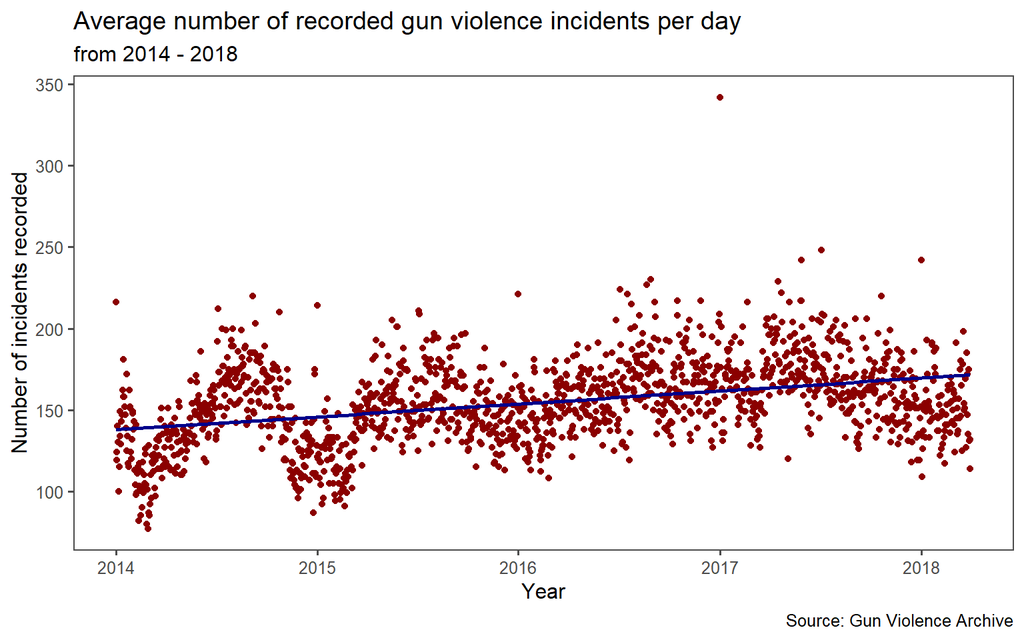

```r
# Finding the number of gun violence incidents per day
gunViolenceWithCensus %>%
  dplyr::filter(year != 2013) %>%
  dplyr::group_by(date) %>%
  dplyr::count() %>%
  dplyr::ungroup() %>%

# Creating a dot plot
  ggplot(aes(x = date, y = n)) +
  stat_summary(geom = "point",
               fun = mean,
               size = 1.5,
               color = "darkred") +
  geom_smooth(aes(x = date,
             y = n),
             method = "lm",
             se = FALSE,
             size = 1,
             color = "darkblue") +
  labs(title = "Average number of recorded gun violence incidents per day",
      subtitle = "from 2014 - 2018",
      x = "Year",
      y = "Number of incidents recorded",
      caption = "Source: Gun Violence Archive") +
  ggthemes::theme_few()
```

Creating a histogram for number of gun violence incidents per year without injuries or deaths.

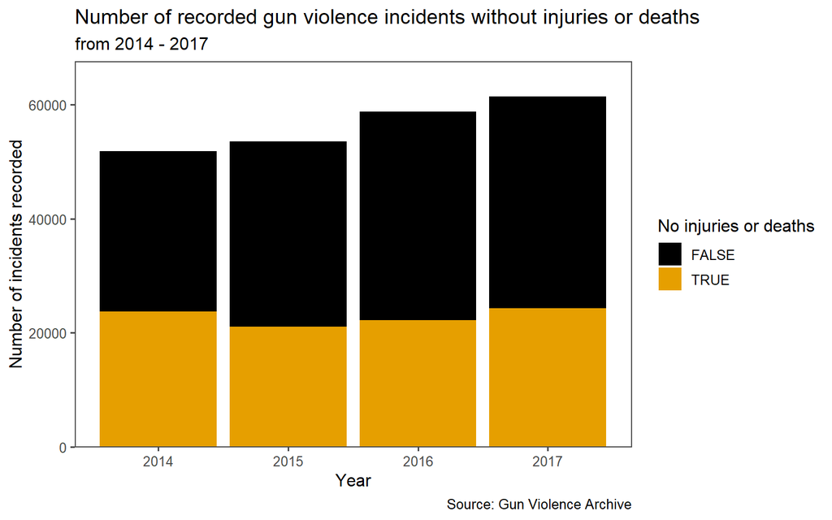

```r
# Getting incidents per year without injuries or deaths
gunViolenceWithCensus %>%
  dplyr::group_by(year) %>%
  dplyr::filter(year != 2013 & year != 2018) %>%
  dplyr::select(year, n_killed, n_injured) %>%
  dplyr::mutate(k = n_killed == 0 & n_injured == 0) %>%
  dplyr::count(k) %>%
  ungroup() %>%

# Creating plot
  ggplot(aes(x = year, y = n, fill = k)) +
  geom_col() +
  scale_y_continuous(expand = expansion(mult = c(0, 0.1))) +
  scale_fill_colorblind() +
  labs(title = "Number of recorded gun violence incidents without injuries or deaths",
      subtitle = "from 2014 - 2017",
      x = "Year",
      y = "Number of incidents recorded",
      caption = "Source: Gun Violence Archive",
      fill = "No injuries or deaths") +
  ggthemes::theme_few()
```

Creating a histogram for the average poverty rate per year.

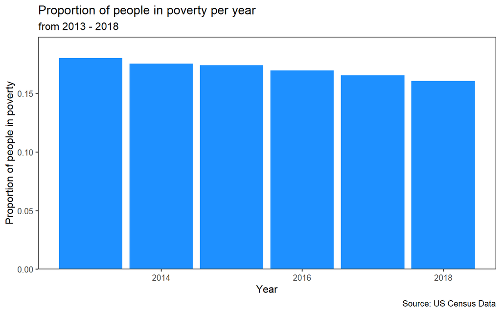

```r
# Getting mean poverty proportion per year
gunViolenceWithCensus %>%
  group_by(year) %>%
  summarize(mean = mean(prop_poverty, na.rm = TRUE)) %>%
  ungroup() %>%

# Creating histogram
  ggplot(aes(x = year, y = mean)) +
  geom_col(fill = "dodgerblue") +
  scale_y_continuous(expand = expansion(mult = c(0, 0.1))) +
  labs(title = "Proportion of people in poverty per year",
      subtitle = "from 2013 - 2018",
      x = "Year",
      y = "Proportion of people in poverty",
      caption = "Source: US Census Data") +
  ggthemes::theme_few()
```

Creating a line graph for the average number of gun violence deaths per day in Chicago, Illinois.

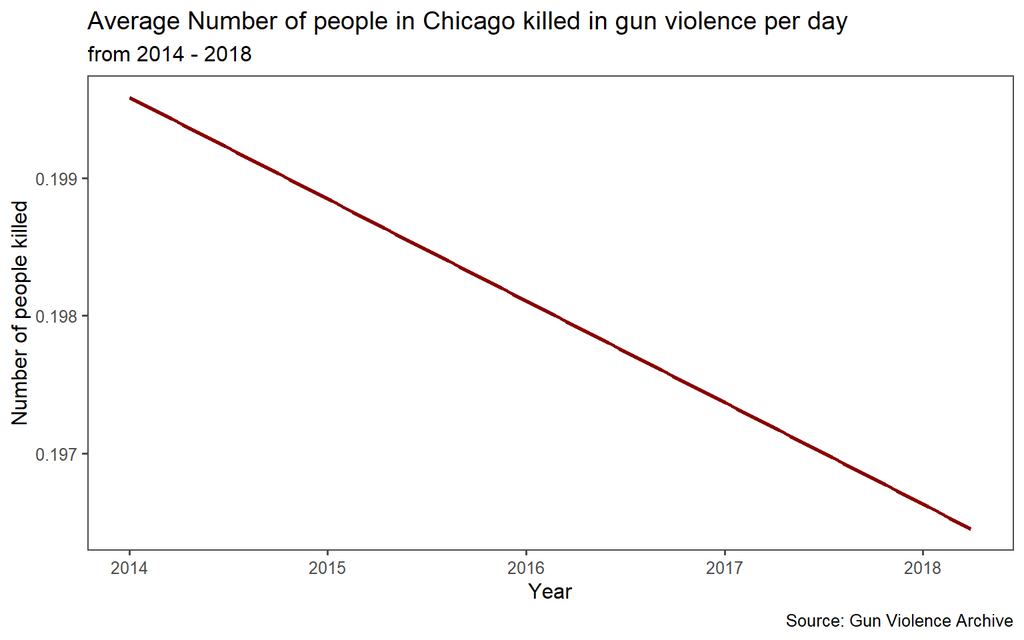

```r
# Getting data from Chicago
gunViolenceWithCensus %>%
  dplyr::filter(geoid == 17031 & year != 2013) %>%

# Creating plot
  ggplot(aes(x = date, y = n_killed)) +
  geom_smooth(aes(x = date,
             y = n_killed),
             method = "lm",
             se = FALSE,
             size = 1,
             color = "darkred") +
  labs(title = "Average Number of people in Chicago killed in gun violence per day",
      subtitle = "from 2014 - 2018",
      x = "Year",
      y = "Number of people killed",
      caption = "Source: Gun Violence Archive") +
  ggthemes::theme_few()
```

Creating a histogram for the proportion of gun violence cases that happen in Chicago per year.

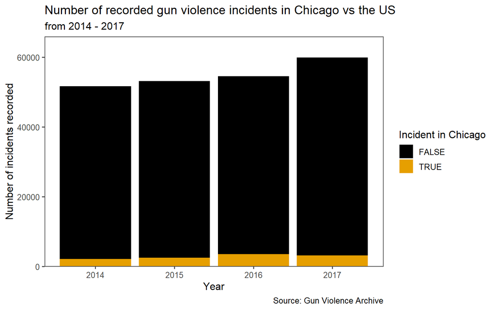

```r
# Getting incidents per year without injuries or deaths
gunViolenceWithCensus %>%
  dplyr::group_by(year) %>%
  dplyr::filter(year != 2013 & year != 2018 & !is.na(geoid)) %>%
  dplyr::select(year, geoid) %>%
  dplyr::mutate(chicago = geoid == 17031) %>%
  dplyr::count(chicago) %>%
  ungroup() %>%

# Creating plot
  ggplot(aes(x = year, y = n, fill = chicago)) +
  geom_col() +
  scale_y_continuous(expand = expansion(mult = c(0, 0.1))) +
  scale_fill_colorblind() +
  labs(title = "Number of recorded gun violence incidents in Chicago vs the US",
      subtitle = "from 2014 - 2017",
      x = "Year",
      y = "Number of incidents recorded",
      caption = "Source: Gun Violence Archive",
      fill = "Incident in Chicago") +
  ggthemes::theme_few()
```

# Monte Carlo Methods of Inference

Getting a table of top 5 county populations for 2018.

```r
countyCensus %>%
  dplyr::filter(year == 2018) %>%
  dplyr::arrange(desc(population)) %>%
  dplyr::select(geoid, county_state, population) %>%
  dplyr::slice_head(n = 5) %>%
  knitr::kable(col.names = c("Geoid (FIPS Code)", "County", "Population"))
```

| Geoid (FIPS Code) | County | Population |
| --- | --- | --- |
| 6037 | Los Angeles County, California | 10098052 |
| 17031 | Cook County, Illinois | 5223719 |
| 48201 | Harris County, Texas | 4602523 |
| 4013 | Maricopa County, Arizona | 4253913 |
| 6073 | San Diego County, California | 3302833 |

Here I will explore the number of gun violence incidents in Cook County, Illinois (Chicago) vs Harris County, Texas (Huston) as they have similar population sizes.

```r
# Getting just the data for incidents in Chicago and Huston
chicagoVsHustonData <- gunViolenceWithCensus %>%
  dplyr::filter(geoid == 17031 | geoid == 48201) %>%
  dplyr::filter(year != 2013 & year != 2018)
```

Given their similar population sizes, it would make sense for them to have a similar number of gun violence incidents each year. Our null hypothesis is that there is no difference in their amount of gun violence incidents.

To start, we’ll implement Welch’s two-sample t-test to test if both cities have similar numbers of gun violence incidents.

```r
# Getting the number of incidents per year
chicagoVsHustonCount <- chicagoVsHustonData %>%
  dplyr::group_by(county_state, year) %>%
  dplyr::count() %>%
  dplyr::mutate(num_incidents = n) %>%
  dplyr::ungroup() %>%
  dplyr::select(county_state, year, num_incidents)

#Implementing a two-sample t-test
tResult <- t_test(x = chicagoVsHustonCount,
                  response = num_incidents,
                  explanatory = county_state,
                  order = c("Cook County, Illinois", "Harris County, Texas"),
                  alternative = "greater")

# Printing the T-Test Results
tResult %>%
  knitr::kable()
```

| statistic | t_df | p_value | alternative | estimate | lower_ci | upper_ci |
| --- | --- | --- | --- | --- | --- | --- |
| 6.64849 | 3.149594 | 0.0029733 | greater | 2122 | 1385.2 | Inf |

This T-test is statistically significant and shows that there is a difference between the two cities amount of gun violence incidents.

To show this, we will create a box plot for the two counties.

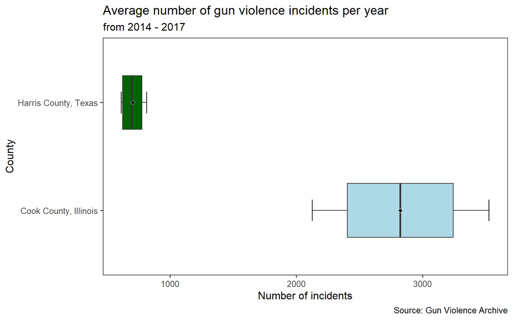

```r
chicagoVsHustonCount %>%
# Creating a box plot
  ggplot(aes(x = county_state, y = num_incidents,
                         fill = county_state)) +
  stat_boxplot(geom = "errorbar", width = 0.2, coef = 1.5) +
  stat_boxplot(geom = "boxplot", width = 0.5, coef = 1.5,
               outlier.shape = 8) +
  stat_summary(fun = "mean", geom = "point", shape = 23, fill = "black",
               color = "white") +
  scale_fill_manual(values = c("lightblue", "darkgreen")) +
    coord_flip() +
    labs(title = "Average number of gun violence incidents per year",
         subtitle = "from 2014 - 2017",
         x = "County",
         y = "Number of incidents",
         caption = "Source: Gun Violence Archive") +
  ggthemes::theme_few() +
  theme(legend.position = "none")
```

```r
# Calculating standard deviations and variances for each group
chicagoVsHustonCount %>%
  group_by(county_state) %>%
  summarize(Mean = mean(num_incidents),
            n = n(),
            SD = sd(num_incidents),
            Variance = var(num_incidents)) %>%
  knitr::kable()
```

| county_state | Mean | n | SD | Variance |
| --- | --- | --- | --- | --- |
| Cook County, Illinois | 2825.75 | 4 | 630.52379 | 397560.25 |
| Harris County, Texas | 703.75 | 4 | 99.59041 | 9918.25 |

We can also implement a randomization test for the data.

```r
# Number of permutations to do
nperms <- 500

# Instantiating vector for test statistics
permTs <- vector(length = nperms)

# Calculating t-test statistic for each permutation
for(p in 1:nperms) {
  permTs[p] <- chicagoVsHustonCount %>%
  dplyr::mutate(county_state = sample(county_state, replace = FALSE)) %>%
  t_test(response = num_incidents,
        explanatory = county_state,
        order = c("Cook County, Illinois", "Harris County, Texas"),
        alternative = "greater") %>%
  pull(statistic)
}
```

We can display the distribution we got from this in a histogram.

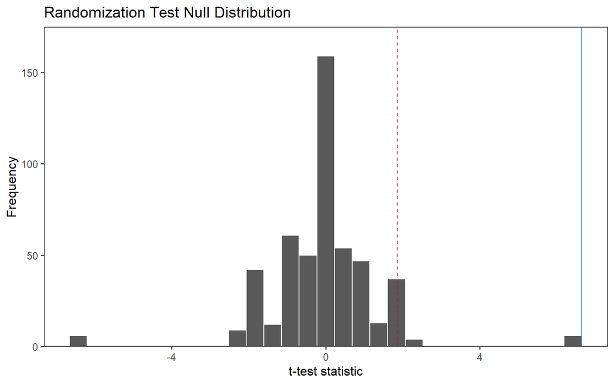

```r
# Turning the vector we have into a tibble in order to use it in ggplot
tidy_ts <- tibble(Statistic = permTs)


# Creating a histogram
tidy_ts %>%
  ggplot(aes(x = Statistic)) +
  geom_histogram(color = "white") +
  labs(title = "Randomization Test Null Distribution",
       y = "Frequency",
       x = "t-test statistic") +
  scale_y_continuous(expand = expansion(mult = c(0, 0.1))) +
  geom_vline(xintercept = quantile(permTs, probs = 0.95), color = "red", lty = "dashed") +
  geom_vline(xintercept = tResult$statistic, color = "dodgerblue") +
  ggthemes::theme_few()
```

Finally, we can calculate the p-value of our randomization test.

```r
# Proportion of randomization test statistics greater than or equal to our observed t-test statistic
mean(permTs >= tResult$statistic)
```

```
## [1] 0.012
```

```r
janitor::tabyl(permTs >= tResult$statistic)
```

```
##  permTs >= tResult$statistic   n percent
##                        FALSE 494   0.988
##                         TRUE   6   0.012
```

This gets us a p-value of 0.01 which means that we reject the null hypothesis.

This means that we have sufficient evidence that Chicago has a greater amount of gun violence incidents per year compared to Huston at the 5% significance level.

# Bootstrap Methods of Inference

To start our bootstrap, we’ll create a subset of our yearly incident data that only has the data from Chicago.

```r
# Subsetting to Chicago
ChicagoData <- chicagoVsHustonCount %>%
  dplyr::filter(county_state == "Cook County, Illinois")
```

We will have a sample size of 4 because that is the amount of years we had data on Chicago for in the original data set.

```r
# Calculating the sample median number of incidents
median(ChicagoData$num_incidents)
```

```
## [1] 2823
```

Half the years recorded more than 2,823 gun violence incidents in Chicago.

Now, we’ll create our bootstrap method.

```r
# Number of bootstrap samples
B <- 10000

# Instantiating matrix for bootstrap samples
boots <- matrix(NA, nrow = 4, ncol = B)

# Sampling with replacement B times
for(b in 1:B) {
boots[, b] <- ChicagoData %>%
  slice_sample(prop = 1, replace = TRUE) %>%
  dplyr::pull(num_incidents)
}
```

We can then get the medians for each of these bootstraps.

```r
# Instantiating vector for bootstrap medians
boot_medians <- vector(length = B)

# Calculating medians for bootstrap samples
for(b in 1:B) {
boot_medians[b] <- median(boots[, b])
}
```

Next, we can create a histogram to show our distribution of sample medians for our bootstrap.

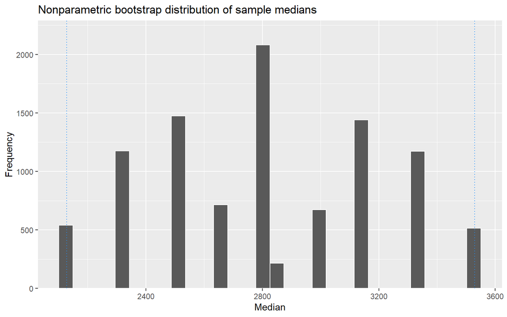

```r
# Visualizing the non-parametric bootstrap distribution
tibble(Median = boot_medians) %>%
  ggplot(aes(x = Median)) +
  geom_histogram(color = "white") +
  labs(title = "Nonparametric bootstrap distribution of sample medians",
       x = "Median",
       y = "Frequency") +
  scale_y_continuous(expand = expansion(mult = c(0, 0.1))) +
  geom_vline(xintercept = quantile(boot_medians, probs = c(0.025)), color = "dodgerblue", lty = "dotted") +
  geom_vline(xintercept = quantile(boot_medians, probs = c(0.975)), color = "dodgerblue", lty = "dotted")
```

```r
# Calculating the standard error
sd(boot_medians)
```

```
## [1] 386.1246
```

```r
# Calculating quantiles of the bootstrap distribution
quantile(boot_medians, probs = c(0.025, 0.975))
```

```
##  2.5% 97.5%
##  2128  3529
```

We are 95% confident that each given year, for at least half of them, Chicago will have between 2,128 and 3,529 gun violence incidents.

# Conclusions / Main Takeaways

Overall, we can be confident that Chicago will have more gun violence incidents than Huston in a given year regardless of their similar population sizes, with a median amount of between 2,128 and 3,529 incidents.